# Analise inicial dos arquivos geraos pelo e-Lattes

# LEMBRAR DE CONFIGURAR O DIRETORIO NO COMANDO setwd()

# Pacotes para serem ativados

```r
library(tidyverse) #Importado para manipulação de tibbles
library(jsonlite) #Importado para carga dos arquivos JSON para o R
library(listviewer) #Importado para análise dos arquivos JSON
library(igraph) #Importado para manipulação de grafo
library(dplyr) #Importado para uso do Operador Pipe
library(tidyr) #Importado para uso da função spread()
library(ggplot2) #Importado para visualizações com ggplot()
library(stringr) #str_to_upper

#CONFIGURAR - DIRETORIO DOS .R
setwd("~/Repository/DataScience/DS4A-BioAni-BioMic-BioMol-PatMol")
source("elattes.ls2df.R")

#CONFIGURAR - DIRETORIO DOS .JSON (Arquivos eLattes)
perfil <- fromJSON("240BiologiaAnimal/240profile.json")
public <- fromJSON("240BiologiaAnimal/240publication.json")
orient <- fromJSON("240BiologiaAnimal/240advise.json")
graphl <- fromJSON("240BiologiaAnimal/240graph.json")

#Arquivos Sucupira? Pesquisar
#res.area <- fromJSON("UnBPosGeral/researchers_by_area.json") #NÃO UTILIZADO
df.prog <- read.table("UnBPosGeral/prof_prog.csv", sep = ",",
                      colClasses = "character", encoding = "UTF-8", header = TRUE)

#SEPARACAO DOS CAMPOS DE DF.PROG - Depende dos arquivos Sucupira
df.prog <- df.prog %>% separate(idLattes.Docente.Categoria.Grande.Area.Area.de.Avaliacao.Codigo.AreaPos.Programa,
                     c("idLattes", "Docente", "Categoria", "GrandeArea", "AreaDeAvaliacao", "Codigo", "AreaPos", "Programa"),
                     sep = ";", extra = "drop", fill = "right")

######
#Analise do arquivo perfil

#jsonedit(perfil)
#jsonedit(public)

#Numero de Docentes encontrados
length(perfil)
```

```
## [1] 19
```

```r
#Atributos presentes em um dos pesquisadores
glimpse(perfil[[1]], width = 30)
```

```
## List of 7
##  $ nome                  : chr "Renato Caparroz"
##  $ resumo_cv             : chr "Formado em Zootecnia pela Universidade Estadual Paulista Júlio de Mesquita Filho - UNESP (1994), mestrado (1998"| __truncated__
##  $ areas_de_atuacao      :'data.frame':  3 obs. of  4 variables:
##   ..$ grande_area  : chr [1:3] "CIENCIAS_BIOLOGICAS" "CIENCIAS_BIOLOGICAS" "CIENCIAS_BIOLOGICAS"
##   ..$ area         : chr [1:3] "Genética" "Genética" "Zoologia"
##   ..$ sub_area     : chr [1:3] "Genética Animal" "Genética Molecular e de Microorganismos" ""
##   ..$ especialidade: chr [1:3] "" "" ""
##  $ endereco_profissional :List of 8
##   ..$ instituicao: chr "Universidade de Brasília"
##   ..$ orgao      : chr "Instituto de Ciências Biológicas"
##   ..$ unidade    : chr "Departamento de Genética e Morfologia"
##   ..$ DDD        : chr "61"
##   ..$ telefone   : chr "31073070"
##   ..$ bairro     : chr "Asa Norte"
##   ..$ cep        : chr "70910900"
##   ..$ cidade     : chr "Brasília"
##  $ producao_bibiografica :List of 3
##   ..$ CAPITULO_DE_LIVRO:'data.frame':    2 obs. of  13 variables:
##   .. ..$ tipo                    : chr [1:2] "Capítulo de livro publicado" "Capítulo de livro publicado"
##   .. ..$ titulo_do_capitulo      : chr [1:2] "Contribuição da análise de marcadores moleculares para a conservação de espécies do gênero Amazona" "Análise de filiação como metodologia para gerenciamento de criadores comerciais e amadorismos de aves no Brasil"
##   .. ..$ titulo_do_livro         : chr [1:2] "PLANO DE AÇÃO NACIONAL PARA A CONSERVAÇÃO DO GÊNERO AMAZONA (papagaios)" "Ciência contra o tráfico: avanços no combate ao comércio ilegal de animais silvestres"
##   .. ..$ ano                     : chr [1:2] "2011" "2017"
##   .. ..$ doi                     : chr [1:2] "" ""
##   .. ..$ pais_de_publicacao      : chr [1:2] "Brasil" "Brasil"
##   .. ..$ isbn                    : chr [1:2] "999999999999X" "9788583320685"
##   .. ..$ nome_da_editora         : chr [1:2] "" "Imprell Gráfica e Editora"
##   .. ..$ numero_da_edicao_revisao: chr [1:2] "" "1"
##   .. ..$ organizadores           : chr [1:2] "Onildo João Marini-Filho" "Fábio José Viana Costa; Juliana Machado Ferreira; Kellen Rejane Gomes Monteiro; Rodrigo Ribeiro Mayink"
##   .. ..$ paginas                 : chr [1:2] " - " "141 - 258"
##   .. ..$ autores                 :List of 2
##   .. ..$ autores-endogeno        :List of 2
##   ..$ EVENTO           :'data.frame':    19 obs. of  11 variables:
##   .. ..$ natureza        : chr [1:19] "RESUMO" "RESUMO" "RESUMO" "RESUMO" ...
##   .. ..$ titulo          : chr [1:19] "Avaliação da eficiência de cinco locos microssatélite para estabelecimento de relações de parentesco no papagaio-charão" "Acréscimo na natureza de araras-canindés (Ara ararauna, Psittaciformes:Aves) provenientes do tráfico ilegal com"| __truncated__ "Incidên…
##   .. ..$ nome_do_evento  : chr [1:19] "2o Congresso de Genética do Centro-oeste" "56o Congresso Brasileiro de Genética" "II Congresso de Genética do Centro-Oeste" "IX Congresso de Ornitologia Neotropical" ...
##   .. ..$ ano_do_trabalho : chr [1:19] "2010" "2010" "2010" "2011" ...
##   .. ..$ pais_do_evento  : chr [1:19] "Brasil" "Brasil" "Brasil" "Brasil" ...
##   .. ..$ cidade_do_evento: chr [1:19] "Goiânia" "Guarujá" "Goiânia" "Cusco" ...
##   .. ..$ doi             : chr [1:19] "" "" "" "" ...
```

[output cut: 58 more lines]

```
##   ..$ OUTRAS_ORIENTACOES_CONCLUIDAS    :'data.frame':    18 obs. of  13 variables:
##   .. ..$ natureza                   : chr [1:18] "INICIACAO_CIENTIFICA" "INICIACAO_CIENTIFICA" "INICIACAO_CIENTIFICA" "INICIACAO_CIENTIFICA" ...
##   .. ..$ titulo                     : chr [1:18] "Biologia reprodutiva e proporção sexual do papagaio-verdadeiro (Amazona aestiva)" "Comportamento reprodutivo do papagaio-de-cara-roxa (Amazona brasiliensis) com base na análise de marcadores mol"| __truncated__ "Diversidade de hemoparasitos presen…
##   .. ..$ ano                        : chr [1:18] "2010" "2010" "2010" "2011" ...
##   .. ..$ id_lattes_aluno            : chr [1:18] "" "" "" "" ...
##   .. ..$ nome_aluno                 : chr [1:18] "Luma Tatiana Silva Castro" "Giovana Colnaghi Abdalla" "Vivian Ribeiro" "Vivian Ribeiro" ...
##   .. ..$ instituicao                : chr [1:18] "Universidade Federal de Goiás" "Universidade Federal de Goiás" "Universidade Federal de Goiás" "Universidade Federal de Goiás" ...
##   .. ..$ curso                      : chr [1:18] "Medicina Veterinária" "Medicina Veterinária" "Ciências Biológicas - Licenciatura" "Ciências Biológicas - Licenciatura" ...
##   .. ..$ codigo_do_curso            : chr [1:18] "90000005" "90000005" "90000008" "90000008" ...
##   .. ..$ bolsa                      : chr [1:18] "NAO" "NAO" "SIM" "SIM" ...
##   .. ..$ agencia_financiadora       : chr [1:18] "" "" "Conselho Nacional de Desenvolvimento Científico e Tecnológico" "Conselho Nacional de Desenvolvimento Científico e Tecnológico" ...
##   .. ..$ codigo_agencia_financiadora: chr [1:18] "" "" "002200000000" "002200000000" ...
##   .. ..$ nome_orientadores          :List of 18
##   .. ..$ id_lattes_orientadores     :List of 18
##  $ senioridade           : chr "9"
```

```r
#Constroi lista de nomes de docentes/pessoas
ProfileList <- list()
for (i in 1:length(perfil)) {
  ProfileList <- rbind(ProfileList, perfil[[i]]$nome)
}

##Analise dos dados em formato list
# Numero de areas de atuacao cumulativo
sum(sapply(perfil, function(x) nrow(x$areas_de_atuacao)))
```

```
## [1] 78
```

```r
# Numero de areas de atuacao por pessoa
table(unlist(sapply(perfil, function(x) nrow(x$areas_de_atuacao))))
```

```
##
## 2 3 4 5 6
## 2 3 7 5 2
```

```r
# Numero de pessoas por grande area
table(unlist(sapply(perfil, function(x) (x$areas_de_atuacao$grande_area))))
```

```
##
##          CIENCIAS_AGRARIAS        CIENCIAS_BIOLOGICAS
##                          2                         68
## CIENCIAS_EXATAS_E_DA_TERRA           CIENCIAS_HUMANAS
##                          2                          5
##                ENGENHARIAS
##                          1
```

```r
# Numero de pessoas que produziram os especificos tipos de producao
table(unlist(sapply(perfil, function(x) names(x$producao_bibiografica))))
```

```
##
##                          ARTIGO_ACEITO
##                                      3
##                      CAPITULO_DE_LIVRO
##                                     14
## DEMAIS_TIPOS_DE_PRODUCAO_BIBLIOGRAFICA
##                                      1
##                                 EVENTO
##                                     15
##                                  LIVRO
##                                      4
##                              PERIODICO
##                                     19
##                       TEXTO_EM_JORNAIS
##                                      4
```

```r
# Numero de publicacoes por tipo
sum(sapply(perfil, function(x) length(x$producao_bibiografica$ARTIGO_ACEITO$ano)))
```

```
## [1] 6
```

```r
sum(sapply(perfil, function(x) length(x$producao_bibiografica$CAPITULO_DE_LIVRO$ano)))
```

```
## [1] 41
```

```r
sum(sapply(perfil, function(x) length(x$producao_bibiografica$LIVRO$ano)))
```

```
## [1] 5
```

```r
sum(sapply(perfil, function(x) length(x$producao_bibiografica$PERIODICO$ano)))
```

```
## [1] 681
```

```r
sum(sapply(perfil, function(x) length(x$producao_bibiografica$TEXTO_EM_JORNAIS$ano)))
```

```
## [1] 4
```

```r
# Numero de pessoas por quantitativo de producoes por pessoa 0 = 1; 1 = 2...
table(unlist(sapply(perfil, function(x) length(x$producao_bibiografica$ARTIGO_ACEITO$ano))))
```

```
##
##  0  2
## 16  3
```

```r
table(unlist(sapply(perfil, function(x) length(x$producao_bibiografica$CAPITULO_DE_LIVRO$ano))))
```

```
##
## 0 1 2 3 4 5 9
## 5 2 7 1 2 1 1
```

```r
table(unlist(sapply(perfil, function(x) length(x$producao_bibiografica$LIVRO$ano))))
```

```
##
##  0  1  2
## 15  3  1
```

```r
table(unlist(sapply(perfil, function(x) length(x$producao_bibiografica$PERIODICO$ano))))
```

```
##
##  10  11  13  18  19  21  23  26  27  33  40  44  57  68 103 104
##   1   1   1   1   3   1   1   2   1   1   1   1   1   1   1   1
```

```r
table(unlist(sapply(perfil, function(x) length(x$producao_bibiografica$TEXTO_EM_JORNAIS$ano))))
```

```
##
##  0  1
## 15  4
```

```r
# Numero de producoes por ano
table(unlist(sapply(perfil, function(x) (x$producao_bibiografica$ARTIGO_ACEITO$ano))))
```

```
##
## 2016 2017
##    1    5
```

```r
table(unlist(sapply(perfil, function(x) (x$producao_bibiografica$CAPITULO_DE_LIVRO$ano))))
```

```
##
## 2010 2011 2012 2013 2014 2015 2016 2017
##    7    9    3    4    3    4    5    6
```

```r
table(unlist(sapply(perfil, function(x) (x$producao_bibiografica$LIVRO$ano))))
```

```
##
## 2013 2014 2016
##    2    1    2
```

```r
table(unlist(sapply(perfil, function(x) (x$producao_bibiografica$PERIODICO$ano))))
```

```
##
## 2010 2011 2012 2013 2014 2015 2016 2017
##   81   81   81   90   90   76   91   91
```

```r
table(unlist(sapply(perfil, function(x) (x$producao_bibiografica$TEXTO_EM_JORNAIS$ano))))
```

```
##
## 2012 2013 2014 2016
##    1    1    1    1
```

```r
# Numero de pessoas que realizaram diferentes tipos de orientacoes
length(unlist(sapply(perfil, function(x) names(x$orientacoes_academicas))))
```

```
## [1] 102
```

```r
# Numero de pessoas por tipo de orientacao
table(unlist(sapply(perfil, function(x) names(x$orientacoes_academicas))))
```

```
##
##               ORIENTACAO_CONCLUIDA_DOUTORADO
##                                           18
##                ORIENTACAO_CONCLUIDA_MESTRADO
##                                           19
##           ORIENTACAO_CONCLUIDA_POS_DOUTORADO
##                                            7
##            ORIENTACAO_EM_ANDAMENTO_DOUTORADO
##                                           16
## ORIENTACAO_EM_ANDAMENTO_INICIACAO_CIENTIFICA
##                                           10
##             ORIENTACAO_EM_ANDAMENTO_MESTRADO
##                                           14
##                OUTRAS_ORIENTACOES_CONCLUIDAS
##                                           18
```

```r
#Numero de orientacoes concluidas
sum(sapply(perfil, function(x) length(x$orientacoes_academicas$ORIENTACAO_CONCLUIDA_MESTRADO$ano)))
```

```
## [1] 136
```

```r
sum(sapply(perfil, function(x) length(x$orientacoes_academicas$ORIENTACAO_CONCLUIDA_DOUTORADO$ano)))
```

```
## [1] 92
```

```r
sum(sapply(perfil, function(x) length(x$orientacoes_academicas$ORIENTACAO_CONCLUIDA_POS_DOUTORADO$ano)))
```

```
## [1] 39
```

```r
# Numero de pessoas por quantitativo de orientacoes por pessoa 0 = 1; 1 = 2...
table(unlist(sapply(perfil, function(x) length(x$orientacoes_academicas$ORIENTACAO_CONCLUIDA_MESTRADO$ano))))
```

```
##
##  1  2  5  6  7  8  9 10 11 12 13
##  1  2  3  2  2  3  1  1  2  1  1
```

```r
table(unlist(sapply(perfil, function(x) length(x$orientacoes_academicas$ORIENTACAO_CONCLUIDA_DOUTORADO$ano))))
```

```
##
##  0  1  2  3  5  6  7  8 10 13
##  1  4  2  2  1  2  2  3  1  1
```

```r
table(unlist(sapply(perfil, function(x) length(x$orientacoes_academicas$ORIENTACAO_CONCLUIDA_POS_DOUTORADO$ano))))
```

```
##
##  0  2  3  5  6  7 14
## 12  2  1  1  1  1  1
```

```r
# Numero de orientacoes por ano
table(unlist(sapply(perfil, function(x) (x$orientacoes_academicas$ORIENTACAO_CONCLUIDA_MESTRADO$ano))))
```

```
##
## 2010 2011 2012 2013 2014 2015 2016 2017
##   17   14   21   26   20   13   19    6
```

```r
table(unlist(sapply(perfil, function(x) (x$orientacoes_academicas$ORIENTACAO_CONCLUIDA_DOUTORADO$ano))))
```

```
##
## 2010 2011 2012 2013 2014 2015 2016 2017
##    2   15   15    4   11   15   11   19
```

```r
table(unlist(sapply(perfil, function(x) (x$orientacoes_academicas$ORIENTACAO_CONCLUIDA_POS_DOUTORADO$ano))))
```

```
##
## 2010 2011 2012 2013 2014 2015 2016
##    3    4    9    5    9    3    6
```

```r
###Analise dos dados em formato Data Frame
#Arquivo Profile por Curriculo
# extrai perfis dos professores
perfil.df.professores <- extrai.perfis(perfil)

# extrai producao bibliografica de todos os professores
perfil.df.publicacoes <- extrai.producoes(perfil) %>%
  select(tipo_producao, everything()) %>% arrange(tipo_producao)
perfil.df.publicacoes$tipo_producao[grepl("DEMAIS",perfil.df.publicacoes$tipo_producao)] <- "OUTRAS_PRODUCOES"

perfil.df.publicacoes %>% select(pais_de_publicacao) %>% distinct()
```

```
##    pais_de_publicacao
## 1                <NA>
## 2              Brasil
## 3          Inglaterra
## 4             Holanda
## 5      Estados Unidos
## 6            Alemanha
## 7             Croácia
## 8             Espanha
## 9        Grã-Bretanha
## 10             México
```

```r
#extrai orientacoes
perfil.df.orientacoes <- extrai.orientacoes(perfil) %>%
  select(id_lattes_orientadores, natureza, ano, orientacao, everything()) %>%
  mutate(situacao = ifelse(grepl("CONCLUIDA", orientacao), "Concluída", "Em andamento")) %>%
  mutate(Natureza = case_when(grepl("MESTRADO", str_to_upper(natureza)) ~ "Mestrado",
                              grepl("PÓS-DOUTORADO", str_to_upper(natureza)) ~ "Pós-doutorado",
                              grepl("DOUTORADO", str_to_upper(natureza)) ~ "Doutorado",
                              grepl("INICIACAO", str_to_upper(natureza)) ~ "Iniciação Científica",
                              grepl("INICIAÇÃO", str_to_upper(natureza)) ~ "Iniciação Científica",
                              TRUE ~ "Outras naturezas"))

perfil.df.orientacoes %>% select(natureza, Natureza) %>% distinct() %>% arrange(Natureza)
```

```
##                                                            natureza
## 1                                                 Tese de doutorado
## 2                                              INICIACAO_CIENTIFICA
## 3                                              Iniciação Científica
## 4                                           Dissertação de mestrado
## 5                                      ORIENTACAO-DE-OUTRA-NATUREZA
## 6                          TRABALHO_DE_CONCLUSAO_DE_CURSO_GRADUACAO
## 7 MONOGRAFIA_DE_CONCLUSAO_DE_CURSO_APERFEICOAMENTO_E_ESPECIALIZACAO
## 8                                       Supervisão de pós-doutorado
##               Natureza
## 1            Doutorado
## 2 Iniciação Científica
## 3 Iniciação Científica
## 4             Mestrado
## 5     Outras naturezas
## 6     Outras naturezas
## 7     Outras naturezas
## 8        Pós-doutorado
```

```r
str_to_upper("pós-doutorado")
```

```
## [1] "PÓS-DOUTORADO"
```

```r
#extrai areas de atuacao
perfil.df.areas.de.atuacao <- extrai.areas.atuacao(perfil) %>%
  select(idLattes, everything())

#cria arquivo com dados quantitativos para analise
perfil.df <- data.frame()
perfil.df <- perfil.df.professores %>%
  select(idLattes, nome, resumo_cv, senioridade) %>%
  left_join(
    perfil.df.orientacoes %>%
      select(orientacao, idLattes) %>%
      filter(!grepl("EM_ANDAMENTO", orientacao)) %>%
      group_by(idLattes) %>%
      count(orientacao) %>%
      spread(key = orientacao, value = n),
    by = "idLattes") %>%
  left_join(
    perfil.df.publicacoes %>%
      select(tipo_producao, idLattes) %>%
      filter(!grepl("ARTIGO_ACEITO", tipo_producao)) %>%
      group_by(idLattes) %>%
      count(tipo_producao) %>%
      spread(key = tipo_producao, value = n),
    by = "idLattes") %>%
  left_join(
    perfil.df.areas.de.atuacao %>%
      select(area, idLattes) %>%
      group_by(idLattes) %>%
      summarise(num_areas = n_distinct(area)),
    by = "idLattes")

glimpse(perfil.df)
```

```
## Observations: 19
## Variables: 15
## $ idLattes                           <chr> "1612292306950738", "186941...
## $ nome                               <chr> "Renato Caparroz", "Monica ...
## $ resumo_cv                          <chr> "Formado em Zootecnia pela ...
## $ senioridade                        <chr> "9", "8", "9", "9", "9", "9...
## $ ORIENTACAO_CONCLUIDA_DOUTORADO     <int> 6, 1, 6, 7, NA, 1, 1, 2, 5,...
## $ ORIENTACAO_CONCLUIDA_MESTRADO      <int> 8, 6, 10, 1, 9, 5, 2, 5, 13...
## $ ORIENTACAO_CONCLUIDA_POS_DOUTORADO <int> NA, NA, NA, NA, NA, NA, NA,...
## $ OUTRAS_ORIENTACOES_CONCLUIDAS      <int> 18, 9, 17, NA, 18, 9, 2, 6,...
## $ CAPITULO_DE_LIVRO                  <int> 2, NA, 4, 9, 1, 4, 2, NA, N...
## $ EVENTO                             <int> 19, 14, 12, NA, 11, 10, 4, ...
## $ LIVRO                              <int> NA, NA, NA, 1, NA, NA, NA, ...
## $ OUTRAS_PRODUCOES                   <int> NA, NA, NA, NA, NA, NA, NA,...
## $ PERIODICO                          <int> 13, 10, 21, 68, 18, 44, 26,...
## $ TEXTO_EM_JORNAIS                   <int> NA, NA, NA, NA, NA, 1, NA, ...
## $ num_areas                          <int> 2, 3, 1, 1, 4, 2, 3, 1, 3, ...
```

```r
####
###Publicacao
##Analise dos dados no formato lista
#Numero de Publicacoes em periódicos
sum(sapply(public$PERIODICO, function(x) length(x$natureza)))
```

```
## [1] 529
```

```r
#anos analisados
names(public$PERIODICO)
```

```
## [1] "2010" "2011" "2012" "2013" "2014" "2015" "2016" "2017"
```

```r
#20 revistas mais publicadas
head(sort(table(as.data.frame(unlist
    (sapply(public$PERIODICO, function(x) unlist(x$periodico)))
  )), decreasing = TRUE),20)
```

```
##
##                                                 Plos One
##                                                       18
##                                         Toxicon (Oxford)
##                                                       14
##                Genetics and Molecular Biology (Impresso)
##                                                       11
##                     Journal of Biomedical Nanotechnology
##                                                        8
##                          Genetics and Molecular Research
##                                                        7
##           International Journal of Nanomedicine (Online)
##                                                        7
##                              Protein and Peptide Letters
##                                                        7
## Revista de la Universidad Industrial de Santander. Salud
##                                                        7
##                             Journal of Nanobiotechnology
##                                                        6
##                                       Scientific Reports
##                                                        6
##                                           Theriogenology
##                                                        6
##                               Behavioural Brain Research
##                                                        5
##                     Frontiers in Behavioral Neuroscience
##                                                        5
##                                Frontiers in Pharmacology
##                                                        5
##                                       Genética na Escola
##                                                        5
##                 Journal of Nanomedicine & Nanotechnology
##                                                        5
##                                             Nanomedicine
##                                                        5
##                                  Small Ruminant Research
##                                                        5
##   Bulletin of Environmental Contamination and Toxicology
##                                                        4
##        Journal of Nanoscience and Nanotechnology (Print)
##                                                        4
```

```r
##Analise dos dados no formato DF
public.periodico.df <- pub.ls2df(public, 1) #artigos
public.livros.df <- pub.ls2df(public, 2) #livros
public.eventos.df <- pub.ls2df(public, 5) #eventos
#Publicacao por ano
table(public.periodico.df$ano)
```

```
##
## 2010 2011 2012 2013 2014 2015 2016 2017
##   70   68   60   70   70   53   66   72
```

```r
#20 revistas mais publicadas
#Mesma visao que anterior mas agora trabalhando no DataFrame
head(sort(table(public.periodico.df$periodico), decreasing = TRUE), 20)
```

```
##
##                                                 Plos One
##                                                       18
##                                         Toxicon (Oxford)
##                                                       14
##                Genetics and Molecular Biology (Impresso)
##                                                       11
##                     Journal of Biomedical Nanotechnology
##                                                        8
##                          Genetics and Molecular Research
##                                                        7
##           International Journal of Nanomedicine (Online)
##                                                        7
##                              Protein and Peptide Letters
##                                                        7
## Revista de la Universidad Industrial de Santander. Salud
##                                                        7
##                             Journal of Nanobiotechnology
##                                                        6
##                                       Scientific Reports
##                                                        6
##                                           Theriogenology
##                                                        6
##                               Behavioural Brain Research
##                                                        5
##                     Frontiers in Behavioral Neuroscience
##                                                        5
##                                Frontiers in Pharmacology
##                                                        5
##                                       Genética na Escola
##                                                        5
##                 Journal of Nanomedicine & Nanotechnology
##                                                        5
##                                             Nanomedicine
##                                                        5
##                                  Small Ruminant Research
##                                                        5
##   Bulletin of Environmental Contamination and Toxicology
##                                                        4
##        Journal of Nanoscience and Nanotechnology (Print)
##                                                        4
```

```r
####
#Orientacao
#Analise dos dados em formato lista
##Numero de Orientacoes Mestrado e Doutorado
sum(sapply(orient$ORIENTACAO_CONCLUIDA_DOUTORADO, function(x) length(x$natureza))) +
  sum(sapply(orient$ORIENTACAO_CONCLUIDA_MESTRADO, function(x) length(x$natureza)))
```

```
## [1] 220
```

```r
##Analise dos dados no formato DF
orient.posdoutorado.df <- ori.ls2df(orient, 6) #pos-Doutorado concluido
orient.doutorado.df <- ori.ls2df(orient, 7) #Doutorado concluido
orient.mestrado.df <- ori.ls2df(orient, 8) #Mestrado concluido

orient.df <- rbind(rbind(orient.posdoutorado.df, orient.doutorado.df), orient.mestrado.df)

###
#Grafo
g <- g.ls2ig(graphl)
df <- as.data.frame(V(g)$name); colnames(df) <- "Idlattes"

#BLOCO ABAIXO REQUER BASE DE DADOS df.prog
df <- left_join(df, df.prog, by = c("Idlattes" = "idLattes")) #

#Apenas para fins de analise inicial, foram retiradas as observacoes
#com duplicacao de pesquisadores no caso de haver professores em mais
#de um programa
df <- df %>% group_by(Idlattes) %>%
  slice(1L)
V(g)$programa <- df$Programa
V(g)$orient_dout <- perfil.df$ORIENTACAO_CONCLUIDA_DOUTORADO
V(g)$orient_mest <- perfil.df$ORIENTACAO_CONCLUIDA_MESTRADO
V(g)$publicacao <- perfil.df$PERIODICO
V(g)$eventos <- perfil.df$EVENTO

#Indice de bolsas

bolsas.df <- orient.df %>% filter(bolsa == "SIM") %>%
  group_by(natureza, ano) %>%
  summarise(num_bolsas = n()) %>%
  inner_join((orient.df %>%
                group_by(natureza, ano) %>%
                summarise(num_orients = n())), by = c("natureza", "ano")) %>%
  mutate(ratio = num_bolsas/num_orients)
```

# Visualizacao

Grafico de barras; periodicos por ano

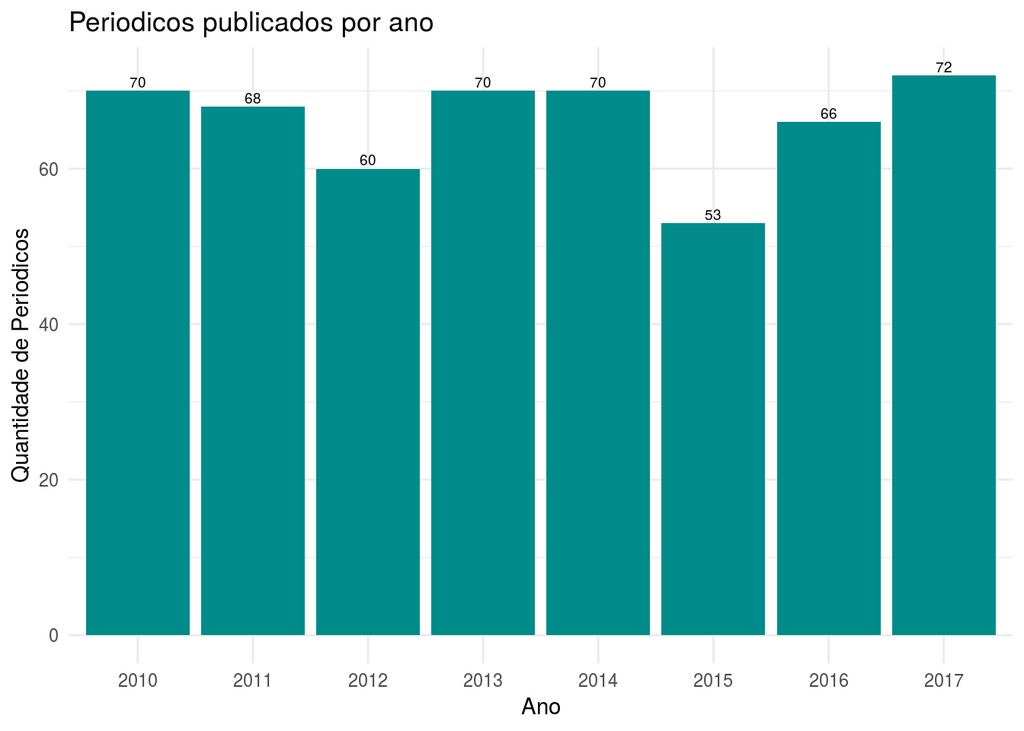

```r
public.periodico.df %>%
  group_by(ano) %>%
  summarise(Quantidade = n()) %>%
  ggplot(aes(ano, Quantidade)) +
  geom_bar(position = "stack",stat = "identity", fill = "darkcyan")+
  ggtitle("Periodicos publicados por ano") +
  geom_text(aes(label=Quantidade), vjust=-0.3, size=2.5)+
  theme_minimal() + labs(x="Ano",y="Quantidade de Periodicos")
```

Sob uma perspectiva de publicações em periódicos, o Programa de Pós-Graduação de Biologia Animal apresentou pouco crescimento entre 2010 e 2017, registrando de 60 a 70 publicações por ano em grande parte da amostra.

Quantidade de periodicos publicados por professor(a) entre 2010 e 2017 Numero de areas de pesquisa do professor

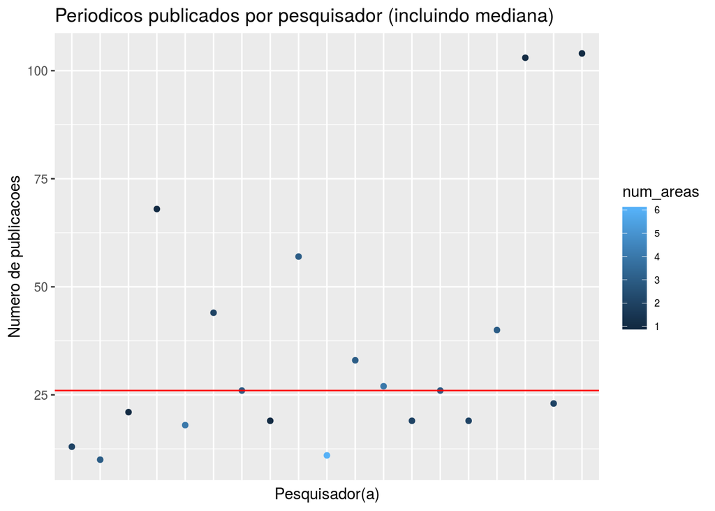

```r
perfil.df %>%
  ggplot(aes(idLattes,PERIODICO, color = num_areas)) +
  geom_point() +
  ggtitle("Periodicos publicados por pesquisador (incluindo mediana)") +
  theme(legend.position="right",legend.text=element_text(size=7)) +
  guides(fill=guide_legend(nrow=5, byrow=TRUE, title.position = "top")) +
  labs(x="Pesquisador(a)",y="Numero de publicacoes") +
  theme(axis.text.x=element_blank(), axis.ticks.x=element_blank()) +
  geom_hline(yintercept = sum(perfil.df %>% summarize(x = median(PERIODICO))), color = "red")
```

publicacao de livros por pais/ano

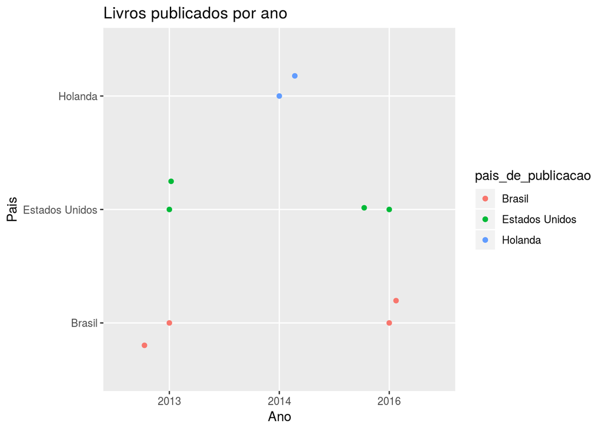

```r
public.livros.df %>%
  group_by(ano,pais_de_publicacao) %>%
  ggplot(aes(x=ano,y=pais_de_publicacao, color= pais_de_publicacao)) +
  ggtitle("Livros publicados por ano") +
  xlab("Ano") + ylab("Pais") + geom_point() + geom_jitter()
```

Apenas três anos apresentaram registros de publicação de livros por parte do Programa no período de 2010 a 2017. Entretanto, uma observação notável é um maior número de publicações em países estrangeiros que no Brasil, o que sinaliza um bom grau de internacionalização do programa.

Eventos nacionais e internacionais

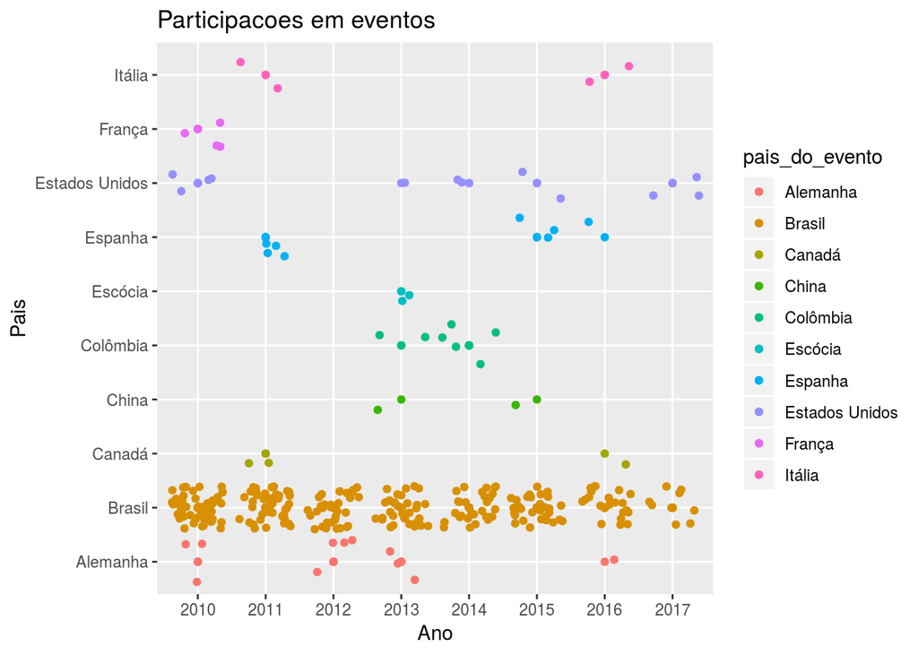

```r
public.eventos.df %>%
  filter(pais_do_evento %in%
           c(names(head(sort(table(public.eventos.df$pais_do_evento)
                             , decreasing = TRUE), 10)))) %>%
  group_by(ano_do_trabalho,pais_do_evento) %>%
  ggplot(aes(x=ano_do_trabalho,y=pais_do_evento, color= pais_do_evento)) +
  ggtitle("Participacoes em eventos") +
  xlab("Ano") + ylab("Pais") + geom_point() + geom_jitter()
```

Considerando eventos, o Programa de Biologia Animal teve comparecimento maior em eventos no Brasil que em países estrangeiros. Ainda assim, o gráfico mostra que o programa esteve presente em pelo menos um evento de sede internacional em todos os anos registrados na base de dados.

# Orientacoes completas por ano e natureza

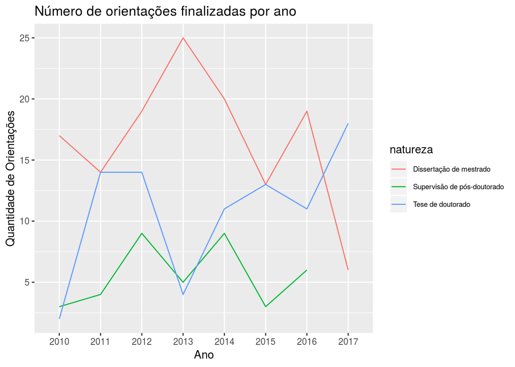

```r
orient.df %>%
  group_by(ano, natureza) %>% summarise(total = n()) %>%
  ggplot(aes(x=ano,y=total,group=natureza,color=natureza)) +
  geom_line() +
  ggtitle("Número de orientações finalizadas por ano") +
  theme(legend.position="right",legend.text=element_text(size=7)) +
  guides(fill=guide_legend(nrow=5, byrow=TRUE, title.position = "top")) +
  labs(x="Ano",y="Quantidade de Orientações")
```

Evolução temporal de orientações em andamento e concluídas

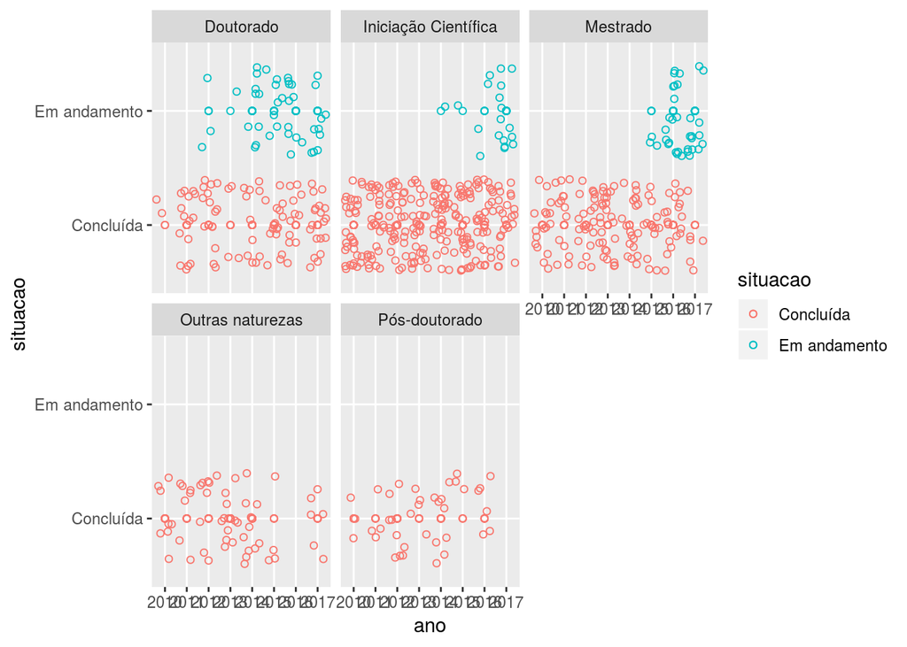

```r
perfil.df.orientacoes %>% group_by(ano, situacao) %>%
  ggplot(aes(x=ano,y=situacao,color=situacao)) +
  geom_point(shape = 1) + geom_jitter(shape = 1) + facet_wrap(. ~ Natureza)
```

Observando a evolução do número de orientações completas ao longo dos anos, percebe-se que o Programa de Pós-Graduação cresceu consideravelmente nas naturezas de doutorado e pós-doutorado após 2010. Entretanto, não há um comportamento linear na evolução do número de orientações finalizadas. A partir de 2011, todos os anos pares apresentaram um aumento no número de pós-doutorados enquanto os anos ímpares seguintes mostram retrocesso neste número. Além disso, o ano de 2017 apresentou um aumento considerável no número de teses de doutorado, mas uma queda vertiginosa nas demais naturezas de orientações - sugerindo uma mudança brusca nas bases do programa.

Índice de bolsas entre naturezas e evolução temporal

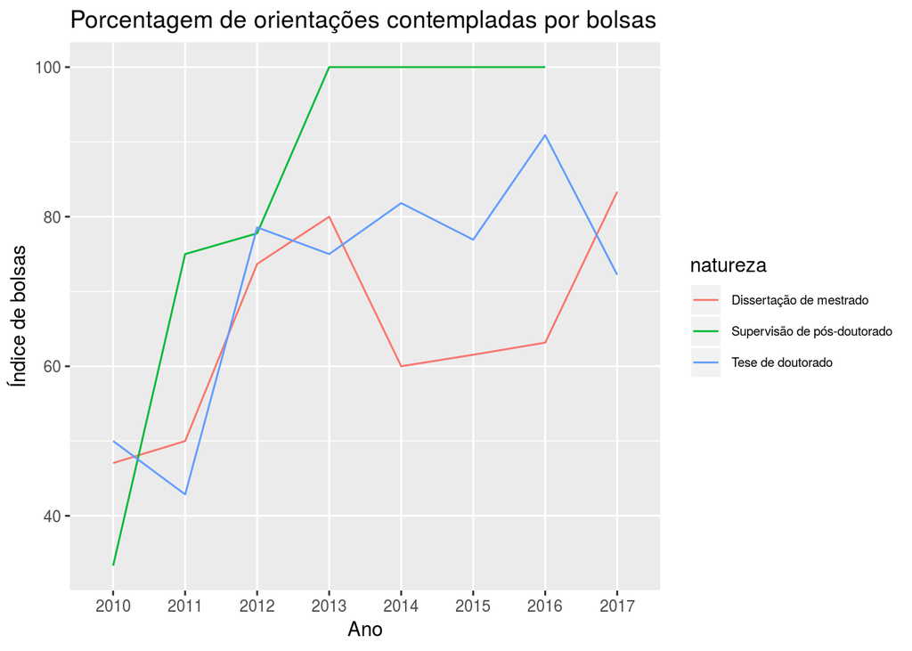

```r
bolsas.df %>%
  ggplot(aes(x=ano,y=ratio*100,color=natureza, group=natureza)) +
  geom_line() + #facet_wrap(. ~ natureza) + #CASO PREFIRA DIVIDIR AS NATUREZAS
  ggtitle("Porcentagem de orientações contempladas por bolsas") +
  theme(legend.position="right",legend.text=element_text(size=7)) +
  guides(fill=guide_legend(nrow=5, byrow=TRUE, title.position = "top")) +
  labs(x="Ano",y="Índice de bolsas")
```

É possível perceber que o número de bolsas oferecidas para o Programa não apresentou um comportamento linear ao longo dos anos. Além disso, as teses de pós-doutorado se mostram a natureza de pesquisa melhor contemplada pelas agências financiadoras, visto que quase todas as observações receberam bolsa. Por fim, é possível observar que os anos com maior número de orientações de mestrado e doutorado também consistem nos anos com maior número de bolsas distribuídas entre o programa, mas a ocorrência de pesquisas realizadas sem este apoio financeiro foi marcante em todo o período.

Grafo de proximidade entre pesquisadores do Programa de Pos-Graduacao

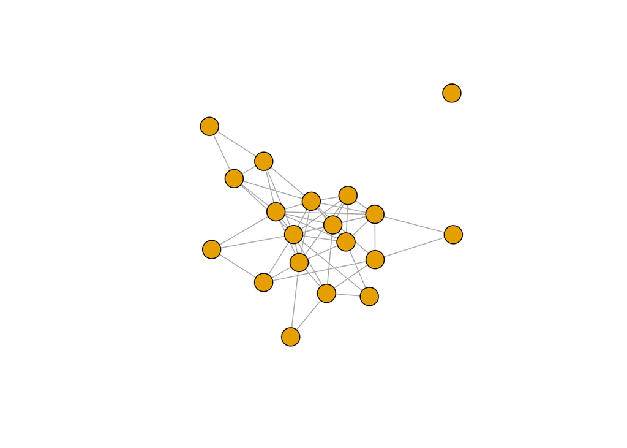

```r
plot(g, vertex.label = NA)
```

O grafo acima representa os pesquisadores do Programa de Pós-Graduação em seus vértices e a existência de cooperação entre eles em suas arestas. Portanto, é possível observar uma considerável cooperação entre os membros do Programa, mas alguns pesquisadores relatam baixa diversidade em suas colaborações no período (2010 a 2017).

Natureza das orientações por tipo de orientação, ano e andamento

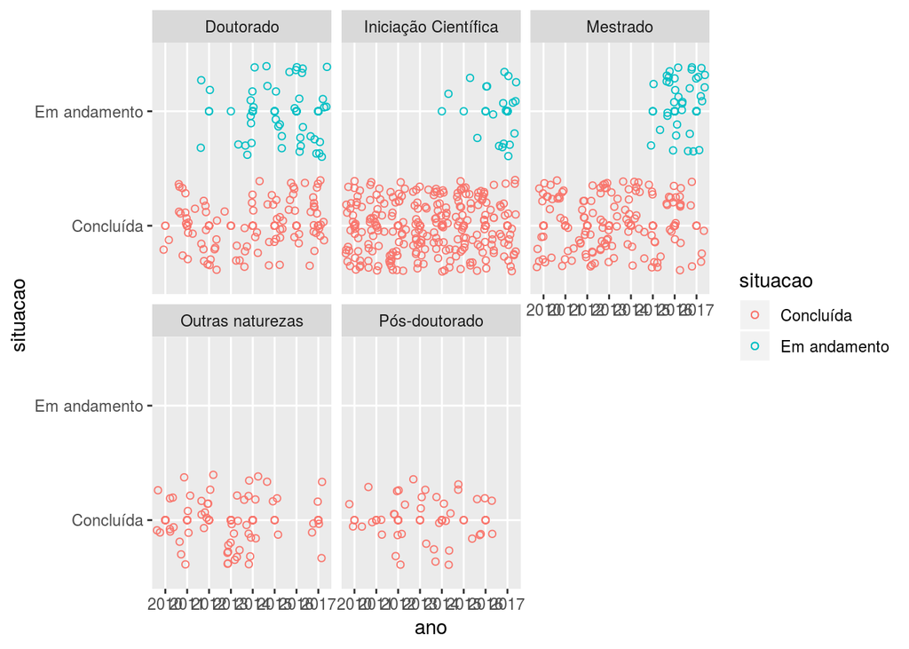

```r
perfil.df.orientacoes %>% group_by(ano, situacao) %>%
  ggplot(aes(x=ano,y=situacao,color=situacao)) +
  geom_point(shape = 1) + geom_jitter(shape = 1) + facet_wrap(. ~ Natureza)
```

A partir do número de orientações por ano e pela natureza destas, percebe-se que a quantidade de orientações de pós graduações no sentido restrito era pequena em proporção a outras orientações conduzidas por PPG por ano, até sua volta em 2015, onde o número de pós graduações no sentido restrito foram maiores que outras orientações.

Mestrados e cursos que mais ocorrem por ano - NÃO CONSEGUI LEGENDA PRA TODOS OS CURSOS

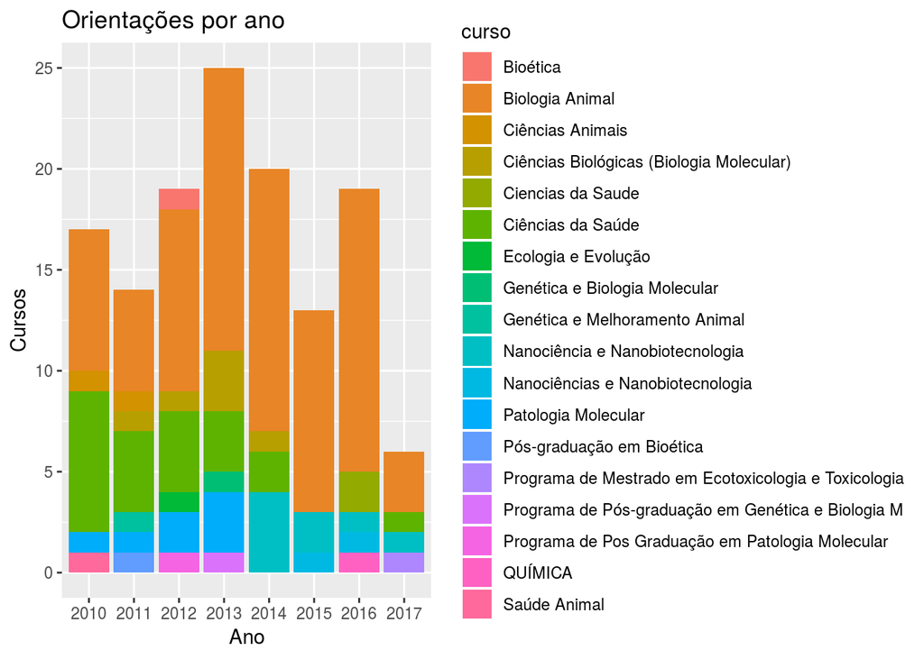

```r
orient.mestrado.df %>%
ggplot(aes(ano, fill=curso)) +
  geom_bar(stat = 'count') +
  ggtitle('Orientações por ano') +
  theme(legend.position = 'right') +
  labs(x='Ano',y='Cursos')
```

Dentre os mestrados nos programas de pós graduação estudados, pode se perceber o grande domínio em volume da pós graduação em Biologia animal, que na maioria dos anos corresponde a quase metade das orientações de pós graduação por ano dentre os PPG estudados.

Publicações de capítulos de livros por ano/país

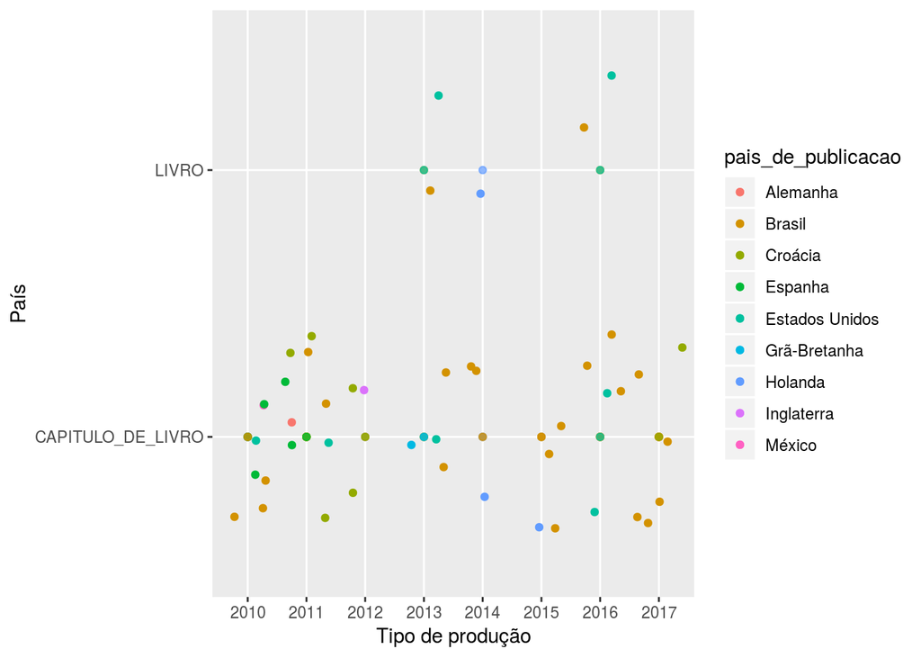

```r
perfil.df.publicacoes %>%
  filter((tipo_producao %in% c('LIVRO', 'CAPITULO_DE_LIVRO'))) %>%
  group_by(tipo_producao,pais_de_publicacao) %>%
  ggplot(aes(ano,tipo_producao,col=pais_de_publicacao)) +
  geom_point(alpha = 0.7) + geom_jitter() +
  labs(x='Tipo de produção',y='País')
```

Observa-se deficiência de dados quanto ao país de publicação para periódicos, textos em jornais e artigos aceitos para os PPG analizados. Ainda assim, este gráfico demonstra bem a heterogeniedade das publicações de livros e/ou capítu- los no Brasil e demais países.

Perfil-Areas - Questao 12

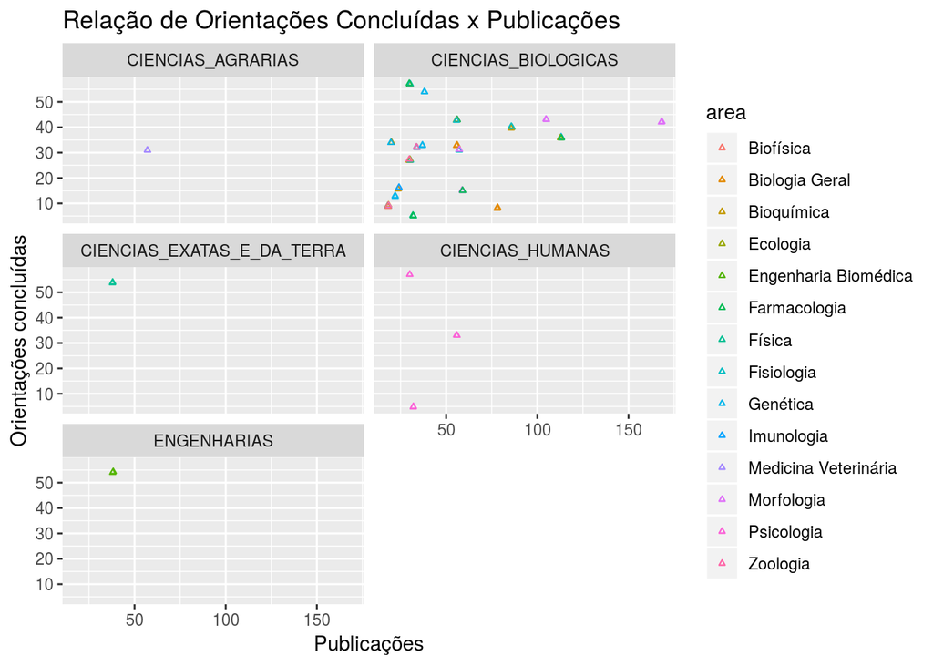

```r
perfil.areas <- perfil.df.areas.de.atuacao %>%
  left_join(perfil.df, by = "idLattes") %>%
  rowwise() %>% #realizar sum() corretamente
  mutate(orientacoes_concluidas = sum(ORIENTACAO_CONCLUIDA_DOUTORADO,
        ORIENTACAO_CONCLUIDA_POS_DOUTORADO, ORIENTACAO_CONCLUIDA_MESTRADO,
        OUTRAS_ORIENTACOES_CONCLUIDAS, na.rm = TRUE)) %>%
  mutate(publicacoes = sum(CAPITULO_DE_LIVRO, EVENTO, PERIODICO,
        LIVRO, TEXTO_EM_JORNAIS, OUTRAS_PRODUCOES, na.rm = TRUE)) %>%
  select(idLattes, grande_area, area, sub_area, especialidade, orientacoes_concluidas, publicacoes)
class(perfil.areas) <- c("tbl_df", "data.frame") #desfazer rowwise

#Graficos ignorando especialidade e subarea
perfil.areas %>%
  select(-sub_area, -especialidade) %>%
  distinct() %>%
  group_by(publicacoes) %>%
  ggplot(aes(publicacoes, orientacoes_concluidas, color = area)) +
  geom_point(shape = 2, size = .8) + geom_jitter(shape = 2, size = .8) +
  ggtitle('Relação de Orientações Concluídas x Publicações') +
  labs(x='Publicações',y='Orientações concluídas') + facet_wrap(. ~ grande_area, ncol = 2)
```

Relação de produção-orientação pelo número de áreas do pesquisador Quem trabalha em mais áreas diferentes publica/orienta mais?

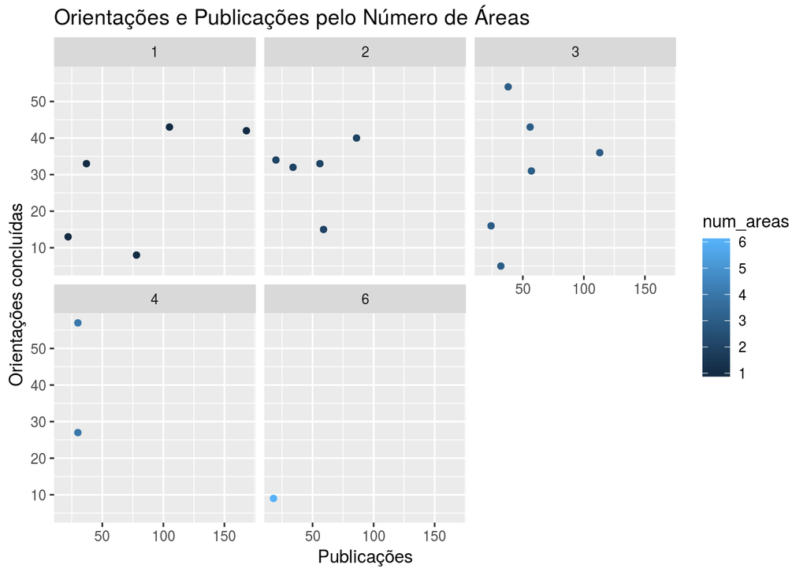

```r
perfil.areas %>%
  select(-sub_area, -especialidade) %>%
  distinct() %>%
  group_by(idLattes, orientacoes_concluidas, publicacoes) %>%
  summarise(num_areas = n()) %>%
  ggplot(aes(publicacoes, orientacoes_concluidas, color = num_areas)) +
  geom_point() +
  ggtitle('Orientações e Publicações pelo Número de Áreas') +
  labs(x='Publicações',y='Orientações concluídas') + facet_wrap(. ~ num_areas)
```

Perfil-Areas - Questao 14

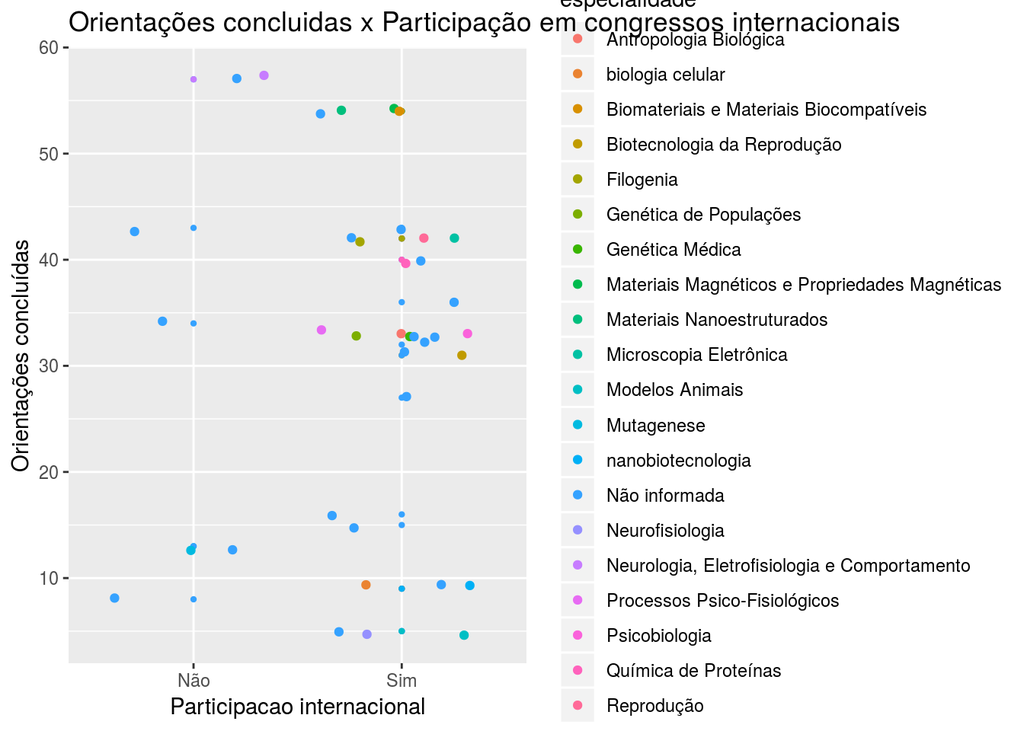

```r
public.eventos.df$`autores-endogeno` <- gsub('\\s+', '', public.eventos.df$`autores-endogeno`)
especialidade.orient <- public.eventos.df %>%
  filter (classificacao == "INTERNACIONAL") %>%
  select (`autores-endogeno`) %>%
  separate_rows(`autores-endogeno`, sep = ";") %>%
  distinct() %>%
  arrange(`autores-endogeno`) %>% mutate(internacional = "Sim") %>%
  right_join(perfil.df, by = c("autores-endogeno" = "idLattes")) %>%
  left_join(perfil.areas, by = c("autores-endogeno" = "idLattes")) %>%
  select(`autores-endogeno`, internacional, especialidade, orientacoes_concluidas) %>% distinct() %>%
  rename(idLattes = `autores-endogeno`)

especialidade.orient[is.na(especialidade.orient)] <- 0 #Remove NAs do dataframe
especialidade.orient$especialidade <- sub("^$", "Não informada", especialidade.orient$especialidade)
especialidade.orient$internacional <- sub(0, "Não", especialidade.orient$internacional)

especialidade.orient %>%
  ggplot(aes(internacional, orientacoes_concluidas, color = especialidade)) +
  geom_point(size = .8) + geom_jitter() +
  ggtitle('Orientações concluidas x Participação em congressos internacionais') +
  labs(x='Participacao internacional',y='Orientações concluídas')
```

Grafo - Questao 15

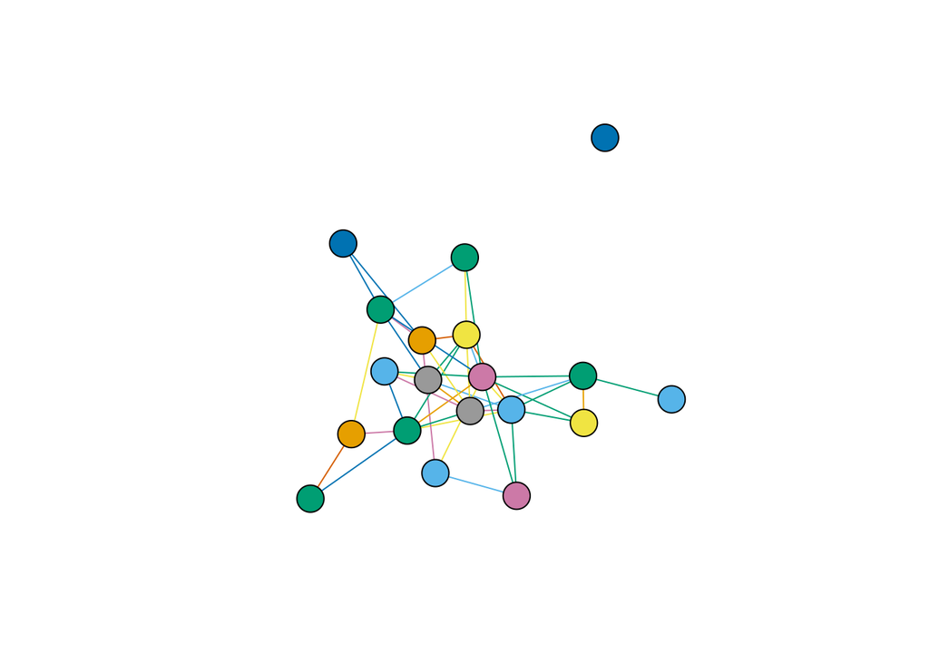

```r
V(g)$programa <- df$Programa
V(g)$orient_dout <- perfil.df$ORIENTACAO_CONCLUIDA_DOUTORADO
V(g)$orient_mest <- perfil.df$ORIENTACAO_CONCLUIDA_MESTRADO
V(g)$publicacao <- perfil.df$PERIODICO
E(g)$eventos <- perfil.df$EVENTO
plot(g, vertex.label = NA,vertex.color=V(g)$publicacao,edge.color=E(g)$eventos)
```